# Laboratorio 3

Joshua Cervantes

26 June 2022

```r
# La persona ahora tiene edad 25, la edad de retiro baja de 60 a 65 y la tasa de interes es 4.3%
#
```

# Ejercicio

Una persona de 25 años de edad posee un plan de pensión que consiste en una anualidad vitalicia pagada al inicio de cada año a partir de la edad 60. Durante el periodo diferido de 35 años se paga un beneficio de fallecimiento (decremento $J=1$) o por retiro (decremento $J=2$) pagado al final del año de ocurrido el suceso y que consiste en el valor acumulado de la primas pagadas a ese momento utlizando la misma tasa de interés que para el cálculo de la prima. Las primas se pagan al inicio de cada año mientras la persona se mantenga activa en el estado/modelo y hasta edad 59 (inclusive). Para este ejercicio se asume que no existe la contingencia de retiro una vez se inicie con el pago de la anualidad vitalicia, así mismo, considere una tasa de interés de 4.3% y como insumo para la tabla de múltiples decrementos utilice el archivo suministrado.

1. Determine las expresiones algebraicas para calcular la prima de con base en el principio de equivalencia, la pérdida y la reserva a un determinado tiempo.
   $$L =
   \begin{cases}
   \pi v^{K+1}\ddot{s}_{\overline{K+1|}}-\pi
   \ddot{a}_{\overline{K+1|}} \qquad K<35, J=1,2\\
   v^{35}\ddot{a}_{\overline{(K+1)-35|}}-\pi
   \ddot{a}_{\overline{35|}}\qquad K\geq 35, J=1
   \end{cases}$$
   Si se aplica el principio de equivalencia se obtiene
   $$\mathbb{E}[L]=\sum_{K=35}^{\infty}\left(v^{35}\ddot{a}_{\overline{(K+1)-35|}}-\pi
   \ddot{a}_{\overline{35|}}\right)_{K}p_{25}^{\tau}q_{25+K}=0$$
   Entonces
   $$\pi =\frac{v^{n}\ddot{a}_{60}}{\ddot{a}_{\overline{35|}}}$$
2. Calcule la prima de riesgo para el ejercicio si se asume que la anualidad vitalica paga 100.000 al inicio de cada año si se aplica.

```r
# El beneficio
benefit <- 100000
interest <- 0.043
v <- 1 / (1 + interest)

# Analidad de pension
a_60_md <- v^(35) * sum(v^(0:15) * pxt(tabla_md, x = 60, 0:15))

# Anualidad primas
a_35 <- (1 - v^(35)) / (1 - v)
# Prima por riesgo
(risk_p <- benefit * a_60_md / a_35)
```

```
## [1] 8356,1
```

3. Estime el valor de la pérdida si la persona falleciera en cada hacia al futuro, grafique e interprete.

```r
L <- benefit * v^35 * (1 - v^(1:15)) / (1 - v) - risk_p * (1 - v^(35)) / (1 - v)
(L <- c(rep(0, 35), L))
```

```
##  [1]       0,0       0,0       0,0       0,0       0,0       0,0       0,0
##  [8]       0,0       0,0       0,0       0,0       0,0       0,0       0,0
## [15]       0,0       0,0       0,0       0,0       0,0       0,0       0,0
## [22]       0,0       0,0       0,0       0,0       0,0       0,0       0,0
## [29]       0,0       0,0       0,0       0,0       0,0       0,0       0,0
## [36] -133335,1 -111368,4  -90307,3  -70114,5  -50754,2  -32192,1  -14395,2
## [43]    2667,9   19027,6   34712,8   49751,4   64169,9   77994,0   91248,2
## [50]  103956,0
```

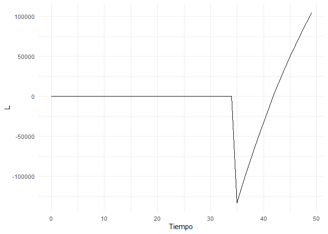

```r
# Graficamos
L <- data.frame(Tiempo = 0:49, L = L)
L %>% ggplot(aes(x = Tiempo, y = L)) +
    geom_line() +
    theme_minimal() +
    scale_color_jcolors(palette = "pal2")
```

**Interpretación**

En este caso se puede ver que en el periodo de 0 a 35 en caso de que suceda el decremento la pérdida es 0, ya que la persona habrá pagado el equivalente en primas del beneficio y acumulado hasta ese periodo mediante la tasa de interés. Posteriormente las péridas son negativas esto se debe a que han acumulado las primas de los 35 perioodos anteriores. Sin embargo, las pérdidas vuelven a aumentar ya que no se obtienen más primas y se debe hacer frente a una anualidad que conforme más viva la persona se vuelve más costosa.

4. Conforme la tabla de flujos para el ejercicio asumiendo que $l_{25}$ individuos toman el indiviuos toman el mismo plan de pensiones.

```r
# Personas que permanecen
filas <- 26:nrow(datos)
lx <- datos$lx[filas]

# Decrementos caso 1
d_1 <- datos$Fallecimiento[filas]

# Decrementos caso 2
d_2 <- datos$Retiro[filas]



# Primas inicio
# Fondos inicio
zeros <- rep(0, length(lx) - 1)
primas <- c(risk_p * lx[1:35], rep(0, 15))

# Intereses
intereses <- c(primas[1] * interest, zeros)

# Reclamos decrementos
reclamos <- 1:35
sn <- risk_p * ((1 + interest)^(reclamos) - 1) / (1 - v)
claim_1 <- c(d_1[1:35] * sn, rep(0, 15))
claim_2 <- c(d_2[1:35] * sn, rep(0, 15))

# Monto pension
pension <- c(rep(0, 35), benefit * lx[36:50])

# Fondos fin
fondos_fin <- c(primas[1] + intereses[1] - claim_1[1] - claim_2[1], zeros)

# Sobrevivientes fin
lx_fin <- c(lx[-1], 0)

# Reserva
reserve <- c(fondos_fin[1] / lx_fin[1], zeros)



# Flujos
flujos <- data.frame(
    "Edad" = 25:74, "Sobrevivientes inicio" = lx, "Prima" = primas,
    "Intereses" = intereses, "Reclamos fallecimiento" = claim_1,
    "Reclamos retiro" = claim_2, "Monto pension" = pension,
    "Fondos esperados fin" = fondos_fin, "Sobrevivientes final" = lx_fin,
    "Reserva observada" = reserve
)
monto_inicio <- 0
for (i in 2:nrow(flujos)) {
    monto_inicio[i] <- (flujos$Prima[i] + flujos$Fondos.esperados.fin[i - 1] - flujos$Monto.pension[i])
    flujos$Intereses[i] <- interest * monto_inicio[i]
    flujos$Fondos.esperados.fin[i] <- monto_inicio[i] + flujos$Intereses[i] - flujos$Reclamos.retiro[i] - flujos$Reclamos.fallecimiento[i]
    flujos$Reserva.observada[i] <- flujos$Fondos.esperados.fin[i] / flujos$Sobrevivientes.final[i]
    if (flujos$Reserva.observada[i] == Inf) {
        flujos$Reserva.observada[i] <- 0
    }
}


# Reserva teorica

reserve <- function(x, t) {
    if (t <= 35) {
        return(risk_p * ((1 + interest)^t - 1) / (1 - v))
    } else {
        k <- 0:15
        pension <- benefit * (sum(v^k * pxt(tabla_md, x = x + t, t = k)))
        return(pension)
    }
}
t <- 1:50
x <- 25
reserva_teorica <- unlist(lapply(FUN = reserve, X = t, x = x))

flujos$Reserva.teorica <- reserva_teorica

nombres <- c(
    "Edad", "Sobrevivientes inicio", "Prima",
    "Intereses", "Reclamos fallecimiento",
    "Reclamos retiro", "Monto pension",
    "Fondos esperados fin", "Sobrevivientes final",
    "Reserva observada", "Reserva teórica"
)
kable(flujos,
    caption = "Flujos", format.args = list(decimal.mark = ",", big.mark = "."),
    col.names = nombres
) %>%
    kable_styling(full_width = F) %>%
    kable_material() %>%
    row_spec(0, bold = T, color = "white", background = "#159957") %>%
    scroll_box(height = "500px", width = "100%")
```

Flujos

| Edad | Sobrevivientes inicio | Prima | Intereses | Reclamos fallecimiento | Reclamos retiro | Monto pension | Fondos esperados fin | Sobrevivientes final | Reserva observada | Reserva teórica |
| --- | --- | --- | --- | --- | --- | --- | --- | --- | --- | --- |
| 25 | 896.795 | 7.493.700.664 | 322.229.128,54890 | 15.164.801 | 1.490.334 | 0 | 7.799.274.657,43107 | 894.884 | 8.715,4 | 8.715,4 |
| 26 | 894.884 | 7.477.732.174 | 656.911.293,74944 | 32.637.607 | 2.777.669 | 0 | 15.898.502.849,91066 | 892.895 | 17.805,6 | 17.805,6 |
| 27 | 892.895 | 7.461.111.909 | 1.004.463.434,62771 | 52.663.159 | 3.847.412 | 0 | 24.307.567.622,80863 | 890.824 | 27.286,6 | 27.286,6 |
| 28 | 890.824 | 7.443.806.444 | 1.365.309.084,88696 | 75.242.884 | 4.609.742 | 0 | 33.036.830.526,35489 | 888.676 | 37.175,3 | 37.175,3 |
| 29 | 888.676 | 7.425.857.561 | 1.739.895.587,74666 | 106.233.520 | 8.975.474 | 0 | 42.087.374.680,82967 | 886.250 | 47.489,3 | 47.489,3 |
| 30 | 886.250 | 7.405.585.684 | 2.128.197.295,68400 | 142.587.976 | 14.678.174 | 0 | 51.463.891.510,15108 | 883.550 | 58.246,7 | 58.246,7 |
| 31 | 883.550 | 7.383.024.238 | 2.530.417.377,17512 | 184.781.513 | 21.882.021 | 0 | 61.170.669.590,77443 | 880.575 | 69.466,7 | 69.466,7 |
| 32 | 880.575 | 7.358.164.867 | 2.946.739.881,69567 | 232.874.455 | 30.681.960 | 0 | 71.212.017.925,02693 | 877.328 | 81.169,2 | 81.169,2 |
| 33 | 877.328 | 7.331.032.640 | 3.377.351.174,28148 | 285.540.401 | 50.795.938 | 0 | 81.584.065.400,60352 | 873.726 | 93.374,9 | 93.374,9 |
| 34 | 873.726 | 7.300.934.000 | 3.822.054.974,21450 | 344.418.157 | 75.440.946 | 0 | 92.287.195.272,08693 | 869.769 | 106.105,4 | 106.105,4 |
| 35 | 869.769 | 7.267.868.947 | 4.280.867.761,44179 | 410.201.171 | 104.699.193 | 0 | 103.321.031.617,08940 | 865.456 | 119.383,3 | 119.383,3 |
| 36 | 865.456 | 7.231.829.127 | 4.753.773.011,98877 | 482.167.444 | 138.694.753 | 0 | 114.685.771.559,21906 | 860.796 | 133.232,2 | 133.232,2 |
| 37 | 860.796 | 7.192.889.743 | 5.240.782.435,97782 | 611.824.236 | 151.516.212 | 0 | 126.356.103.289,31815 | 855.627 | 147.676,6 | 147.676,6 |
| 38 | 855.627 | 7.149.697.108 | 5.740.749.417,08496 | 759.680.205 | 164.044.054 | 0 | 138.322.825.555,18616 | 849.951 | 162.742,1 | 162.742,1 |
| 39 | 849.951 | 7.102.267.935 | 6.253.279.020,08941 | 926.719.056 | 177.206.244 | 0 | 150.574.447.210,90573 | 843.765 | 178.455,4 | 178.455,4 |
| 40 | 843.765 | 7.050.577.156 | 6.777.876.047,78098 | 1.113.535.849 | 190.168.152 | 0 | 163.099.196.413,45877 | 837.074 | 194.844,4 | 194.844,4 |
| 41 | 837.074 | 6.994.666.551 | 7.314.036.107,46946 | 1.249.163.344 | 294.805.940 | 0 | 175.863.929.787,51291 | 829.789 | 211.938,1 | 211.938,1 |
| 42 | 829.789 | 6.933.792.428 | 7.860.302.055,25516 | 1.393.536.088 | 415.188.741 | 0 | 188.849.299.441,58032 | 821.917 | 229.766,9 | 229.766,9 |
| 43 | 821.917 | 6.868.013.279 | 8.415.844.446,98749 | 1.550.028.815 | 552.109.286 | 0 | 202.031.019.065,76639 | 813.453 | 248.362,3 | 248.362,3 |
| 44 | 813.453 | 6.797.287.324 | 8.979.617.174,78142 | 1.717.127.128 | 706.075.821 | 0 | 215.384.720.616,30414 | 804.403 | 267.757,2 | 267.757,2 |
| 45 | 804.403 | 6.721.664.701 | 9.550.574.568,62645 | 2.006.975.799 | 852.151.153 | 0 | 228.797.832.933,30460 | 794.475 | 287.986,2 | 287.986,2 |
| 46 | 794.475 | 6.638.705.429 | 10.123.771.149,56827 | 2.324.010.154 | 1.013.489.732 | 0 | 242.222.809.625,39868 | 783.677 | 309.085,0 | 309.085,0 |
| 47 | 783.677 | 6.548.476.358 | 10.697.165.297,27332 | 2.673.229.246 | 1.191.927.828 | 0 | 255.603.294.206,41708 | 772.003 | 331.091,1 | 331.091,1 |
| 48 | 772.003 | 6.450.927.351 | 11.268.331.526,96483 | 3.053.270.127 | 1.387.850.058 | 0 | 268.881.432.899,66373 | 759.459 | 354.043,4 | 354.043,4 |
| 49 | 759.459 | 6.346.108.545 | 11.834.784.282,11636 | 3.741.650.257 | 1.714.907.285 | 0 | 281.605.768.184,81372 | 745.023 | 377.982,7 | 377.982,7 |
| 50 | 745.023 | 6.225.480.015 | 12.376.743.672,57711 | 4.502.980.860 | 2.077.213.990 | 0 | 293.627.797.022,66364 | 728.693 | 402.951,3 | 402.951,3 |
| 51 | 728.693 | 6.089.025.048 | 12.887.823.349,03751 | 5.340.970.526 | 2.476.151.155 | 0 | 304.787.523.739,02795 | 710.471 | 428.993,6 | 428.993,6 |
| 52 | 710.471 | 5.936.760.357 | 13.361.144.216,13140 | 6.260.737.600 | 2.913.922.899 | 0 | 314.910.767.812,84662 | 690.358 | 456.155,7 | 456.155,7 |
| 53 | 690.358 | 5.768.694.298 | 13.789.216.870,76511 | 7.400.521.282 | 3.133.654.445 | 0 | 323.934.503.253,77600 | 668.615 | 484.485,8 | 484.485,8 |
| 54 | 668.615 | 5.587.007.810 | 14.169.424.975,76362 | 8.647.596.325 | 3.366.409.578 | 0 | 331.676.930.136,59521 | 645.243 | 514.034,1 | 514.034,1 |
| 55 | 645.243 | 5.391.709.251 | 14.493.951.493,65433 | 10.010.584.357 | 3.612.375.458 | 0 | 337.939.631.066,14008 | 620.240 | 544.853,0 | 544.853,0 |
| 56 | 620.240 | 5.182.781.906 | 14.754.263.757,82137 | 11.492.628.091 | 3.871.650.492 | 0 | 342.512.398.147,96350 | 593.612 | 576.997,1 | 576.997,1 |
| 57 | 593.612 | 4.960.275.914 | 14.941.324.984,67498 | 12.891.811.493 | 3.962.907.198 | 0 | 345.559.280.355,73993 | 566.005 | 610.523,4 | 610.523,4 |
| 58 | 566.005 | 4.729.589.309 | 15.062.421.395,58007 | 14.398.328.457 | 4.048.521.298 | 0 | 346.904.441.304,63123 | 537.427 | 645.491,3 | 645.491,3 |
| 59 | 537.427 | 4.490.788.939 | 15.109.994.900,48392 | 16.025.443.987 | 4.127.238.904 | 0 | 346.352.542.252,96570 | 507.876 | 681.962,8 | 681.962,8 |
| 60 | 507.876 | 0 | 12.709.292.516,87752 | 0 | 0 | 50.787.600.000 | 308.274.234.769,84320 | 477.358 | 645.792,5 | 645.792,5 |
| 61 | 477.358 | 0 | 11.203.152.695,10326 | 0 | 0 | 47.735.800.000 | 271.741.587.464,94647 | 446.273 | 608.913,4 | 608.913,4 |
| 62 | 446.273 | 0 | 9.765.914.360,99270 | 0 | 0 | 44.627.300.000 | 236.880.201.825,93918 | 414.624 | 571.313,3 | 571.313,3 |
| 63 | 414.624 | 0 | 8.402.965.478,51538 | 0 | 0 | 41.462.400.000 | 203.820.767.304,45456 | 382.406 | 532.995,7 | 532.995,7 |
| 64 | 382.406 | 0 | 7.119.947.194,09154 | 0 | 0 | 38.240.600.000 | 172.700.114.498,54611 | 349.631 | 493.949,7 | 493.949,7 |
| 65 | 349.631 | 0 | 5.922.691.623,43748 | 0 | 0 | 34.963.100.000 | 143.659.706.121,98358 | 316.397 | 454.048,9 | 454.048,9 |
| 66 | 316.397 | 0 | 4.816.860.263,24529 | 0 | 0 | 31.639.700.000 | 116.836.866.385,22888 | 282.710 | 413.274,6 | 413.274,6 |
| 67 | 282.710 | 0 | 3.808.332.254,56484 | 0 | 0 | 28.271.000.000 | 92.374.198.639,79372 | 248.569 | 371.624,0 | 371.624,0 |
| 68 | 248.569 | 0 | 2.903.243.841,51113 | 0 | 0 | 24.856.900.000 | 70.420.542.481,30484 | 213.974 | 329.107,9 | 329.107,9 |
| 69 | 213.974 | 0 | 2.107.995.126,69611 | 0 | 0 | 21.397.400.000 | 51.131.137.608,00095 | 179.071 | 285.535,6 | 285.535,6 |
| 70 | 179.071 | 0 | 1.428.633.617,14404 | 0 | 0 | 17.907.100.000 | 34.652.671.225,14499 | 143.864 | 240.871,0 | 240.871,0 |
| 71 | 143.864 | 0 | 871.449.662,68123 | 0 | 0 | 14.386.400.000 | 21.137.720.887,82623 | 108.349 | 195.089,2 | 195.089,2 |
| 72 | 108.349 | 0 | 443.021.298,17653 | 0 | 0 | 10.834.900.000 | 10.745.842.186,00275 | 72.538 | 148.140,9 | 148.140,9 |
| 73 | 72.538 | 0 | 150.157.813,99812 | 0 | 0 | 7.253.800.000 | 3.642.200.000,00087 | 36.422 | 100.000,0 | 100.000,0 |
| 74 | 36.422 | 0 | 0,00004 | 0 | 0 | 3.642.200.000 | 0,00091 | 0 | 0,0 | 0,0 |

5. Se grafica e interpreta el vector de reservas.

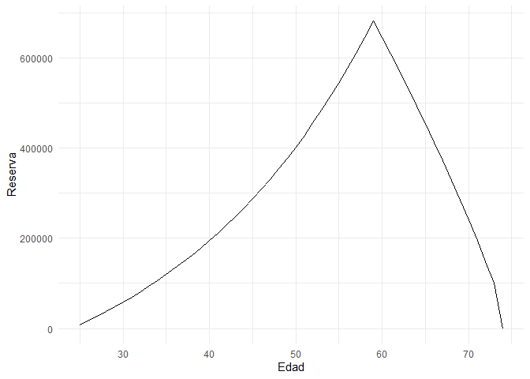

```r
# Edad
Edad <- 25:74
Reserva <- flujos$Reserva.teorica
Reserva <- data.frame("Edad" = Edad, "Reserva" = Reserva)
Reserva %>% ggplot(aes(x = Edad, y = Reserva)) +
    geom_line() +
    theme_minimal()
```

**Interpretación**

Se puede observar que conforme avanza el tiempo se aumentan las reservas por lo menos en el periodo de diferimiento, debido a que se logran obtener primas y acumular intereses sobre estas y los montos anteriormente recibos. Al tenerse una mayor cantidad en reservas que decrementos durante el periodo de diferimiento es posible hacer la acumulación de primas sobre estos. Posteriormente llegado el periodo 35 las reservas comienzan a decrecer, esto se debe a que ya no se reciben las primas y además hay que hacer frente al pago de la anualidad vitalicia los montos de reclamo no superan inicialmente los montos en reserva por lo que se pueden seguir acumulando intereses sobre esta, pero finalmente tanto los reclamos como las reservas son iguales por lo que la reserva se hace 0, ya no se siguen acumulando intereses y todos los individuos del grupo bajo el modelo han muerto.